# Library

```python
!pip install vaderSentiment
```

```python
import re
import math
import nltk
import collections
import numpy as np
import pandas as pd
import seaborn as sns
import matplotlib.pyplot as plt
from nltk.corpus import stopwords
from vaderSentiment.vaderSentiment import SentimentIntensityAnalyzer

nltk.download('stopwords')
stop_words = set(stopwords.words('english'))
```

# **Task 1: Read the important features of the tweets of Kevin Rudd and Scott Morrison into a single Pandas dataframe. The important features are those that you need for the subsequent tasks.**

```python
kevin = pd.read_json('/content/kevin.json')
scott = pd.read_json('/content/scott.json')
```

```python
kevin['user'] = 'Kevin'
scott['user'] = 'Scott'
raw = pd.concat([kevin, scott], ignore_index=True)
data = raw.loc[:, ['id', 'created_at', 'full_text', 'entities', 'user']]
```

```python
def extract_media(entities):
    if isinstance(entities, dict) and 'media' in entities:
        if isinstance(entities, dict) and 'type' in entities['media'][0]:
            return entities['media'][0]['type']
    else:
        return None
def extract_urls(entities):
    if isinstance(entities, dict) and 'urls' in entities and len(entities['urls'])>0:
        if 'url' in entities['urls'][0]:
            return entities['urls'][0]['url']
    else:
        return None

data['media_type'] = data['entities'].apply(extract_media)
data['url'] = data['entities'].apply(extract_urls)
```

```python
data.head()
```

|  | id | created_at | full_text | entities | user | media_type | url |
| --- | --- | --- | --- | --- | --- | --- | --- |
| 0 | 1445292895808856066 | 2021-10-05 07:40:53+00:00 | Is this incompetence or corruption?! Frydenber... | {'hashtags': [], 'symbols': [], 'user_mentions... | Kevin | None | https://t.co/QLUPCQCQtz |
| 1 | 1445263011434811393 | 2021-10-05 05:42:08+00:00 | Murdoch's global empire has been promoting the... | {'hashtags': [{'text': 'MurdochRoyalCommission... | Kevin | None | https://t.co/3ZKpxswe3U |
| 2 | 1444842005863927808 | 2021-10-04 01:49:12+00:00 | How strange to see Alexander Downer—in an arti... | {'hashtags': [], 'symbols': [], 'user_mentions... | Kevin | None | https://t.co/IjifnrtJvy |
| 3 | 1444618617870422016 | 2021-10-03 11:01:32+00:00 | Murdoch’s Credlin rewriting the history of COV... | {'hashtags': [], 'symbols': [], 'user_mentions... | Kevin | photo | None |
| 4 | 1444592732530307075 | 2021-10-03 09:18:41+00:00 | Great that Qld is hosting the Grand Final. I’v... | {'hashtags': [], 'symbols': [], 'user_mentions... | Kevin | None | https://t.co/46zXioFESP |

# **Task 2: Use pandas to plot the posting times of the tweets for the two users in one bar chart; the aim of the plot is to distinguish the two users.**

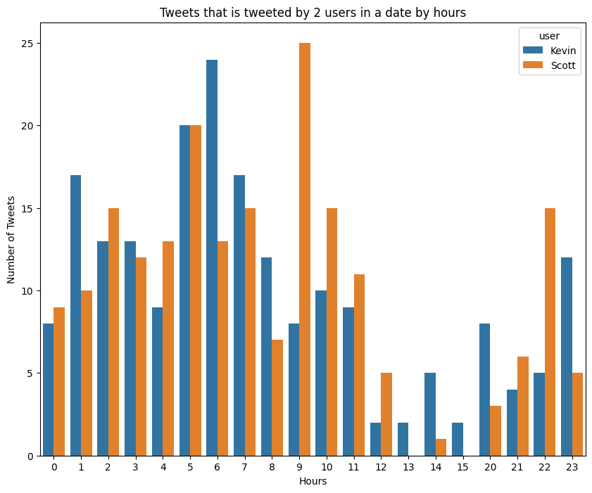

```python
data['created_hour'] = data['created_at'].dt.hour

plt.figure(figsize=(10, 8))
sns.countplot(x='created_hour', hue='user', data=data)
plt.title('Tweets that is tweeted by 2 users in a date by hours')
plt.xlabel('Hours')
plt.ylabel('Number of Tweets')
plt.show()
```

# **Task 3: Use pandas to construct one bar chart of the proportions of tweets for each of the two users that contain pictures or links.**

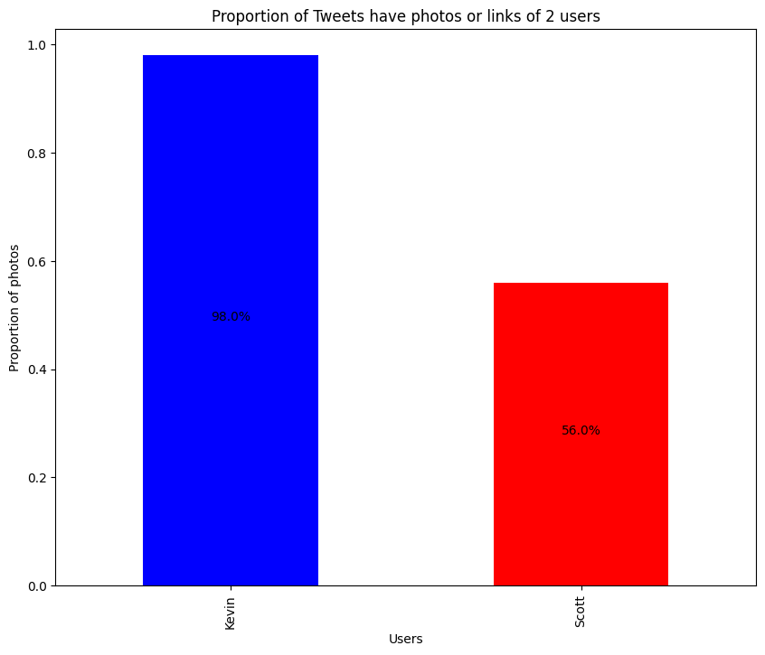

```python
tweet_with_url = data[data['url'].notna()].groupby(['user']).size()
tweet_with_photo = data[data['media_type']=='photo'].groupby(['user']).size()
tweet_with_both = data[(data['url'].notna()) & (data['media_type']=='photo')].groupby(['user']).size()

plotprepare = ((tweet_with_photo + tweet_with_url- tweet_with_both)/data.groupby(['user']).size())
plotprepare.plot(kind='bar', figsize=(10, 8), color=['blue', 'red'])

plt.title('Proportion of Tweets have photos or links of 2 users')
plt.xlabel('Users')
plt.ylabel('Proportion of photos')
plt.text(0, plotprepare['Kevin']/2, str(plotprepare['Kevin']*100)+'%', ha = 'center')
plt.text(1, plotprepare['Scott']/2, str(round(plotprepare['Scott']*100,2))+'%', ha = 'center')
plt.show()
```

# **Task 4: Use pandas to construct a histogram of the number of hashtags in tweets for each of the two users.**

```python
def get_hashtag(data):
    hashtag_list = []
    for i in data.iterrows():
        pack = i[1]['entities']['hashtags'][:] if len(i[1]['entities']['hashtags'])!=0 else None
        draft = []
        if pack is not None:
                if len(pack) == 1:
                    draft.append([pack[0]['text']])
                else:
                    list_draft = []
                    list_draft.append(pack[0]['text'])
                    for i in range(1,len(pack)):
                        list_draft.append(pack[i]['text'])
                    draft.append(list_draft)
        else:
            draft.append([])
        hashtag_list.extend(draft)
    return hashtag_list
```

```python
data['hashtag'] = get_hashtag(data)
data['num_hashtag'] = data['hashtag'].apply(lambda x: len(x) if isinstance(x, list) else 0)
```

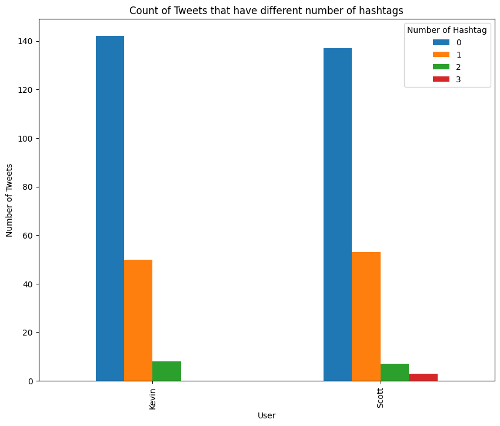

```python
data.groupby(['user', 'num_hashtag']).size().unstack().plot(kind='bar', figsize=(10, 8))
plt.xlabel('User')
plt.ylabel('Number of Tweets')
plt.title('Count of Tweets that have different number of hashtags')
plt.legend(title="Number of Hashtag")
plt.show()
```

# **Task 5: Calculate the log odds ratio for each word used in the set of tweets, and list the 20 words most strongly associated with each of the two users.**

```python
def process_text(data_text):
    url_pattern = r'https?://\S+|www\.\S+'
    pattern = r'([^A-Za-z\d#@\'"]|\'(?![A-Za-z\d#@]))'
    process_text = data_text.apply(lambda x: re.sub(url_pattern, '', x))
    process_text = process_text.apply(lambda x: re.split(pattern, x))
    process_text = process_text.apply(lambda words: [word for word in words if re.search(r'[A-Za-z]', word)])
    return process_text

data['process_text'] = process_text(data['full_text'])
```

```python
def remove_stop_words(data, name=data['user']):
    data_word=[]
    for i in data[data['user']==name]['process_text']:
        data_word.extend(i)
    filtered_word = [w.lower() for w in data_word if not w.lower() in stop_words]
    frequency_data = collections.Counter(filtered_word)
    return frequency_data, filtered_word

frequency_kevin, filtered_kevin_word = remove_stop_words(data,'Kevin')
frequency_scott, filtered_scott_word = remove_stop_words(data,'Scott')
frequency_data, filtered_data_word = remove_stop_words(data)
```

```python
def plot_frequency(frequency_data, filtered_data_word, name='Data', ax=None):
    list_log_word = {}
    for i in frequency_data.items():
        log_word = math.log((i[1]+1)/(len(filtered_data_word)+1))
        list_log_word[i[0]]=log_word

    list_log_word= sorted(list_log_word.items(), key=lambda x: x[1], reverse=True)

    if ax == None:
        fig, ax = plt.subplots(figsize=(10, 8))
        word = [i[0] for i in list_log_word[:20]]
        logodd = [i[1] for i in list_log_word[:20]]
        sns.barplot(x=logodd, y=word, data=data, ax=ax)
        plt.xlabel('Log Odds Ratio')
        plt.ylabel('Words')
        plt.title('Top 20 words have highest log ratio of '+ name)
        plt.show()
    else:
        word = [i[0] for i in list_log_word[:20]]
        logodd = [i[1] for i in list_log_word[:20]]
        sns.barplot(x=logodd, y=word, data=data, ax=ax)
        ax.set_xlabel('Log Odds Ratio')
        ax.set_ylabel('Words')
        ax.set_title('Top 20 words have highest log ratio of '+ name)
    return list_log_word
```

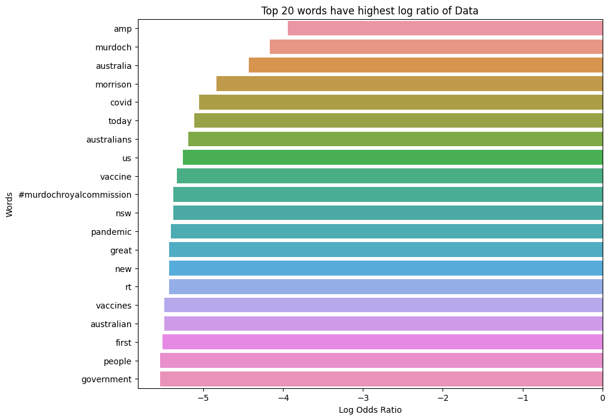

```python
list_log_word = plot_frequency(frequency_data, filtered_data_word)
```

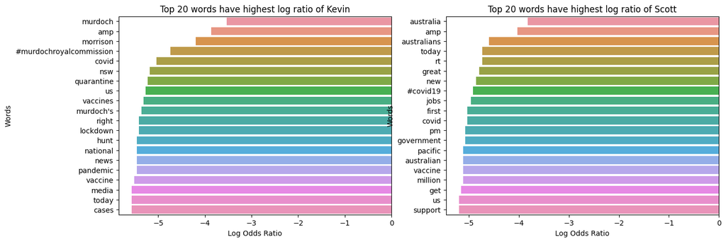

```python
fig, ax = plt.subplots(nrows=1, ncols=2, figsize=(15, 5))
plot_frequency(frequency_kevin, filtered_kevin_word, name='Kevin', ax=ax[0])
plot_frequency(frequency_scott, filtered_scott_word, name='Scott', ax=ax[1])
plt.show()
```

# **Task 6: Use the vaderSentiment module to calculate the sentiment of each tweet, and then for each of the two users, calculate the average 'compound' sentiment for all their tweets.**

```python
analyzer = SentimentIntensityAnalyzer()
def calculate_Vadercompound(sentence):
    return analyzer.polarity_scores(sentence)['compound']

data['VaderCompound'] = data['full_text'].apply(calculate_Vadercompound)
```

```python
data['VaderCompound'].head()
```

```
0   -0.4574
1   -0.0772
2   -0.4019
3   -0.7964
4    0.2244
Name: VaderCompound, dtype: float64
```

```python
Kevin_Sentiment = data[data['user'] == 'Kevin']['VaderCompound'].mean()
Scott_Sentiment = data[data['user'] == 'Scott']['VaderCompound'].mean()
print("Average compound score of Kevin's tweets is {}".format(round(Kevin_Sentiment, 3)))
print("Average compound score of Scott's tweets is {}".format(round(Scott_Sentiment, 3)))
```

```
Average compound score of Kevin's tweets is -0.185
Average compound score of Scott's tweets is 0.471
```

```python
for compound in data['VaderCompound']:
    if compound >= 0.05:
        data.loc[data['VaderCompound'] == compound, 'Sentiment'] = 'Positive'
    elif compound <= -0.05:
        data.loc[data['VaderCompound'] == compound, 'Sentiment'] = 'Negative'
    else:
        data.loc[data['VaderCompound'] == compound, 'Sentiment'] = 'Neutral'
```

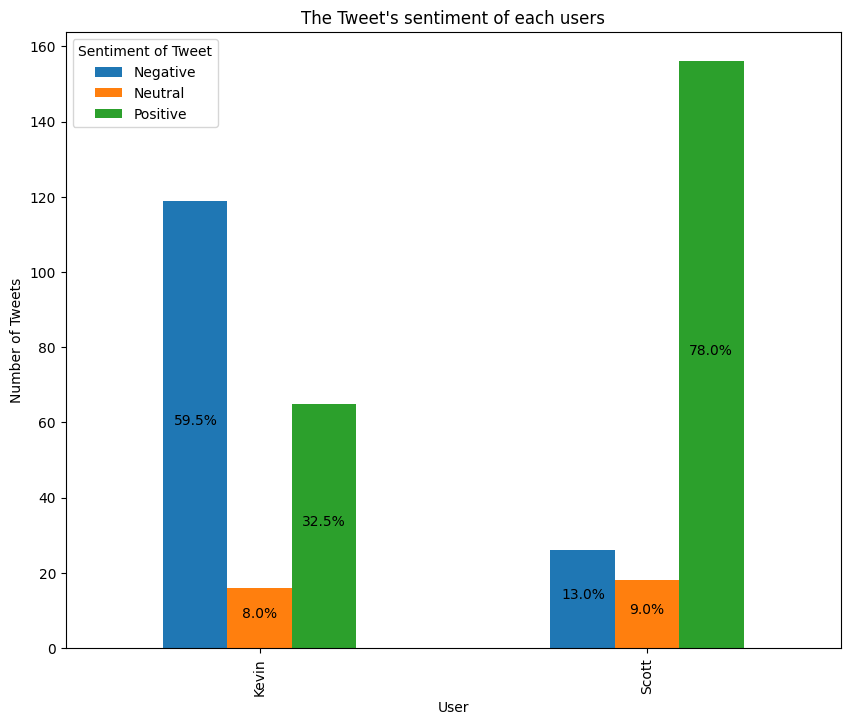

```python
sentiment_plot=data.groupby(['user', 'Sentiment']).size().unstack()
sentiment_plot.plot(kind='bar', figsize=(10, 8))
plt.xlabel('User')
plt.ylabel('Number of Tweets')
plt.title("The Tweet's sentiment of each users")
plt.legend(title="Sentiment of Tweet")
plt.text(0.165, sentiment_plot['Positive']['Kevin']/2, str(sentiment_plot['Positive']['Kevin']/2) + "%", ha = 'center')
plt.text(0, sentiment_plot['Neutral']['Kevin']/2, str(sentiment_plot['Neutral']['Kevin']/2) + "%", ha = 'center')
plt.text(-0.165, sentiment_plot['Negative']['Kevin']/2, str(sentiment_plot['Negative']['Kevin']/2) + "%", ha = 'center')

plt.text(1.165, sentiment_plot['Positive']['Scott']/2, str(sentiment_plot['Positive']['Scott']/2) + "%", ha = 'center')
plt.text(1, sentiment_plot['Neutral']['Scott']/2, str(sentiment_plot['Neutral']['Scott']/2) + "%", ha = 'center')
plt.text(0.835, sentiment_plot['Negative']['Scott']/2, str(sentiment_plot['Negative']['Scott']/2) + "%", ha = 'center')
plt.show()
```